# Linear Models

Linh Tran

11/21/2020

# Linear models

Load and cleans the `airbnb` data.

```r
data("nyc_airbnb")

nyc_airbnb =
  nyc_airbnb %>%
  mutate(stars = review_scores_location / 2) %>%
  rename(
    borough = neighbourhood_group,
    neighborhood = neighbourhood) %>%
  filter(borough != "Staten Island") %>%
  select(price, stars, borough, neighborhood, room_type)
```

## Model fitting

Scatterplot:

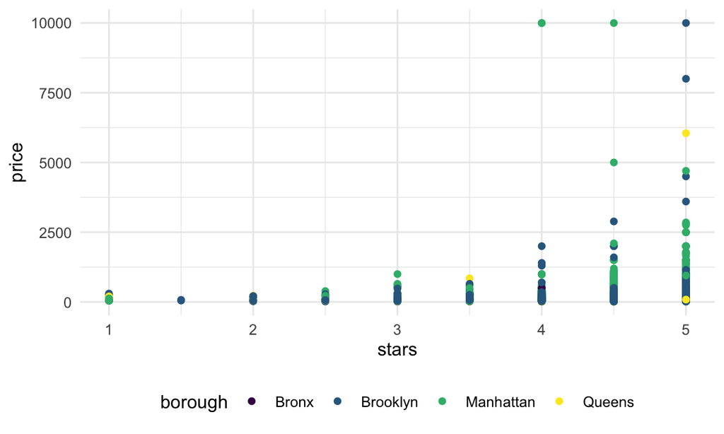

```r
#price = continuous variable, stars = numeric predictor, borough = categorical predictor

nyc_airbnb %>%
  ggplot(aes(x = stars, y = price, color = borough)) +
  geom_point()
```

Fit a model consider price as an outcome that may depend on rating and borough

```r
fit = lm(price ~ stars + borough, data = nyc_airbnb)
summary(fit)
```

```
##
## Call:
## lm(formula = price ~ stars + borough, data = nyc_airbnb)
##
## Residuals:
##    Min     1Q Median     3Q    Max
## -169.8  -64.0  -29.0   20.2 9870.0
##
## Coefficients:
##                  Estimate Std. Error t value Pr(>|t|)
## (Intercept)       -70.414     14.021  -5.022 5.14e-07 ***
## stars              31.990      2.527  12.657  < 2e-16 ***
## boroughBrooklyn    40.500      8.559   4.732 2.23e-06 ***
## boroughManhattan   90.254      8.567  10.534  < 2e-16 ***
## boroughQueens      13.206      9.065   1.457    0.145
## ---
## Signif. codes:  0 '***' 0.001 '**' 0.01 '*' 0.05 '.' 0.1 ' ' 1
##
## Residual standard error: 181.5 on 30525 degrees of freedom
##   (9962 observations deleted due to missingness)
## Multiple R-squared:  0.03423,    Adjusted R-squared:  0.03411
## F-statistic: 270.5 on 4 and 30525 DF,  p-value: < 2.2e-16
```

You can also specify an intercept-only model (outcome ~ 1), a model with no intercept (outcome ~ 0 + …), and a model using all available predictors (outcome ~ .).

R will treat categorical (factor) covariates predictably: indicator variables are created for each non-reference category and included in your model, and the factor level is treated as the reference. Being careful with factors is therefore critical!

```r
nyc_airbnb =
  nyc_airbnb %>%
  mutate(
    borough = fct_infreq(borough),
    room_type = fct_infreq(room_type))

fit = lm(price ~ stars + borough, data = nyc_airbnb)
```

**Note**: Changing reference categories won’t change “fit” or statistical significance, but can affect ease of interpretation.

### Be in control of factors

R treat categorical (factor) covariates as such: indicator variables are created for each non-reference category and included in model, and the factor level is treated as the reference.

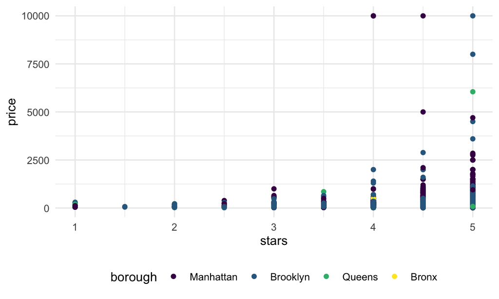

```r
nyc_airbnb =
  nyc_airbnb %>%
  mutate(
    borough = fct_infreq(borough),
    room_type = fct_infreq(room_type)
  )

nyc_airbnb %>%
  ggplot(aes(x = stars, y = price, color = borough)) +
  geom_point()
```

Refit my model: now Manhattan is the reference

```r
fit = lm(price ~ stars + borough, data = nyc_airbnb)

broom::tidy(fit)
```

```
## # A tibble: 5 x 5
##   term            estimate std.error statistic   p.value
##   <chr>              <dbl>     <dbl>     <dbl>     <dbl>
## 1 (Intercept)         19.8     12.2       1.63 1.04e-  1
## 2 stars               32.0      2.53     12.7  1.27e- 36
## 3 boroughBrooklyn    -49.8      2.23    -22.3  6.32e-109
## 4 boroughQueens      -77.0      3.73    -20.7  2.58e- 94
## 5 boroughBronx       -90.3      8.57    -10.5  6.64e- 26
```

## Tidying output

The `broom` package has functions for obtaining a quick summary of the model and for cleaning up the coefficient table. Both of these functions produce df.

```r
broom::tidy(fit) %>% #structured as a df
  select(-std.error, -statistic) %>%
  mutate(
    term = str_replace(term, "borough", "Borough: ")
  ) %>%
  knitr::kable(digits = 3)
```

| term | estimate | p.value |
| --- | --- | --- |
| (Intercept) | 19.839 | 0.104 |
| stars | 31.990 | 0.000 |
| Borough: Brooklyn | -49.754 | 0.000 |
| Borough: Queens | -77.048 | 0.000 |
| Borough: Bronx | -90.254 | 0.000 |

## Diagnostics

Regression diagnostics can identify issues in model fit, especially related to certian failures in model assumptions. Examining residuals and fitted values are therefore an important component of any modeling exercise.  
The `modelr` package can be used to add residuals and fitted values to a dataframe.

```r
modelr::add_residuals(data = nyc_airbnb, model = fit)
```

```
## # A tibble: 40,492 x 6
##    price stars borough neighborhood room_type        resid
##    <dbl> <dbl> <fct>   <chr>        <fct>            <dbl>
##  1    99   5   Bronx   City Island  Private room      9.47
##  2   200  NA   Bronx   City Island  Private room     NA
##  3   300  NA   Bronx   City Island  Entire home/apt  NA
##  4   125   5   Bronx   City Island  Entire home/apt  35.5
##  5    69   5   Bronx   City Island  Private room    -20.5
##  6   125   5   Bronx   City Island  Entire home/apt  35.5
##  7    85   5   Bronx   City Island  Entire home/apt  -4.53
##  8    39   4.5 Bronx   Allerton     Private room    -34.5
##  9    95   5   Bronx   Allerton     Entire home/apt   5.47
## 10   125   4.5 Bronx   Allerton     Entire home/apt  51.5
## # … with 40,482 more rows
```

```r
# First one is $9.47 higher than what my model predicts.

modelr::add_predictions(nyc_airbnb, fit)
```

```
## # A tibble: 40,492 x 6
##    price stars borough neighborhood room_type        pred
##    <dbl> <dbl> <fct>   <chr>        <fct>           <dbl>
##  1    99   5   Bronx   City Island  Private room     89.5
##  2   200  NA   Bronx   City Island  Private room     NA
##  3   300  NA   Bronx   City Island  Entire home/apt  NA
##  4   125   5   Bronx   City Island  Entire home/apt  89.5
##  5    69   5   Bronx   City Island  Private room     89.5
##  6   125   5   Bronx   City Island  Entire home/apt  89.5
##  7    85   5   Bronx   City Island  Entire home/apt  89.5
##  8    39   4.5 Bronx   Allerton     Private room     73.5
##  9    95   5   Bronx   Allerton     Entire home/apt  89.5
## 10   125   4.5 Bronx   Allerton     Entire home/apt  73.5
## # … with 40,482 more rows
```

Look at distribution of residuals:

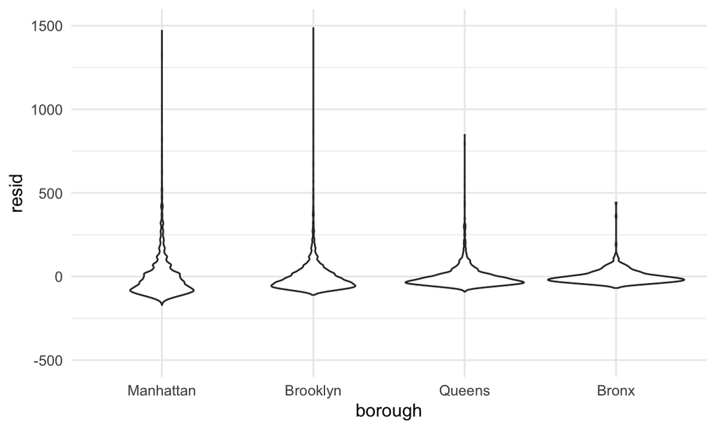

```r
nyc_airbnb %>%
  modelr::add_residuals(fit) %>%
  ggplot(aes(x = borough, y = resid)) + geom_violin() +
  ylim(-500, 1500)
```

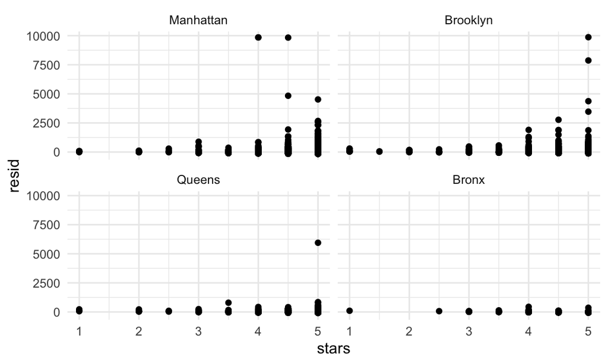

```r
#Distributions of residuals are skewed.

nyc_airbnb %>%
  modelr::add_residuals(fit) %>%
  ggplot(aes(x = stars, y = resid)) +
  geom_point() +
  facet_wrap(. ~ borough)
```

```r
#Distributions of residual spread out as star counts increases.
```

For exclusion of outliers: transform the price variable (e.g. using a log transformation), or fitting a model that is robust to outliers. E.g: a combination of median regression, which is less sensitive to outliers than OLS, maybe bootstrapping for inference.  
For this example, I’d probably use a combination of median regression, which is less sensitive to outliers than OLS, and maybe bootstrapping for inference. If that’s not feasible, I’d omit rentals with price over $1000 (< 0.5% of the sample) from the primary analysis and examine these separately. I usually avoid transforming the outcome, because the results model is difficult to interpret.)

## Hypothesis testing

- Model summaries include results of t-tests for single coefficients, and are the standard way of assessing statistical significance.
- Testing multiple coef is somewhat more complicated. A useful approach is to use `nested models`, meaning that the terms in a simple “null” model are a subset of the terms in a more complex “alternative” model.
- Test of this kind are required to assess the significance of a categorical predictor with more than 2 levels, as in this example:

```r
fit_null = lm(price ~ stars + borough, data = nyc_airbnb)
fit_alt = lm(price ~ stars + borough + room_type, data = nyc_airbnb)

summary(fit_null)
```

```
##
## Call:
## lm(formula = price ~ stars + borough, data = nyc_airbnb)
##
## Residuals:
##    Min     1Q Median     3Q    Max
## -169.8  -64.0  -29.0   20.2 9870.0
##
## Coefficients:
##                 Estimate Std. Error t value Pr(>|t|)
## (Intercept)       19.839     12.189   1.628    0.104
## stars             31.990      2.527  12.657   <2e-16 ***
## boroughBrooklyn  -49.754      2.235 -22.262   <2e-16 ***
## boroughQueens    -77.048      3.727 -20.675   <2e-16 ***
## boroughBronx     -90.254      8.567 -10.534   <2e-16 ***
## ---
## Signif. codes:  0 '***' 0.001 '**' 0.01 '*' 0.05 '.' 0.1 ' ' 1
##
## Residual standard error: 181.5 on 30525 degrees of freedom
##   (9962 observations deleted due to missingness)
## Multiple R-squared:  0.03423,    Adjusted R-squared:  0.03411
## F-statistic: 270.5 on 4 and 30525 DF,  p-value: < 2.2e-16
```

```r
summary(fit_alt)
```

```
##
## Call:
## lm(formula = price ~ stars + borough + room_type, data = nyc_airbnb)
##
## Residuals:
##    Min     1Q Median     3Q    Max
## -211.9  -47.1  -16.8   14.2 9923.2
##
## Coefficients:
##                       Estimate Std. Error t value Pr(>|t|)
## (Intercept)            112.544     11.800   9.538  < 2e-16 ***
## stars                   21.879      2.427   9.014  < 2e-16 ***
## boroughBrooklyn        -40.315      2.149 -18.758  < 2e-16 ***
## boroughQueens          -55.456      3.591 -15.444  < 2e-16 ***
## boroughBronx           -63.035      8.218  -7.670 1.76e-14 ***
## room_typePrivate room -104.873      2.049 -51.181  < 2e-16 ***
## room_typeShared room  -129.198      6.147 -21.017  < 2e-16 ***
## ---
## Signif. codes:  0 '***' 0.001 '**' 0.01 '*' 0.05 '.' 0.1 ' ' 1
##
## Residual standard error: 173.7 on 30523 degrees of freedom
##   (9962 observations deleted due to missingness)
## Multiple R-squared:  0.1151, Adjusted R-squared:  0.1149
## F-statistic: 661.4 on 6 and 30523 DF,  p-value: < 2.2e-16
```

The test of interest is implemented in the `anova` function which, of course, can be summarized using `broom::tidy()` - only for `nested` models.

```r
anova(fit_null, fit_alt) %>%
  broom::tidy()
```

```
## # A tibble: 2 x 6
##   res.df         rss    df     sumsq statistic p.value
##    <dbl>       <dbl> <dbl>     <dbl>     <dbl>   <dbl>
## 1  30525 1005601724.    NA       NA        NA       NA
## 2  30523  921447496.     2 84154228.     1394.       0
```

## Nesting data

- Fitting models to datasets nested within variables, meaning, that we’ll use `nest` to create a list column containing datasets and fit separate models to each.

In the airbnb data, we might think that star ratings and room type affects price differently in each borough. One way to allow this kind of effect modification is through interaction terms:

```r
#interaction

fit = lm(price ~ stars * borough + room_type * borough, data = nyc_airbnb)

broom::tidy(fit)
```

```
## # A tibble: 16 x 5
##    term                                  estimate std.error statistic  p.value
##    <chr>                                    <dbl>     <dbl>     <dbl>    <dbl>
##  1 (Intercept)                              95.7      19.2     4.99   6.13e- 7
##  2 stars                                    27.1       3.96    6.84   8.20e-12
##  3 boroughBrooklyn                         -26.1      25.1    -1.04   2.99e- 1
##  4 boroughQueens                            -4.12     40.7    -0.101  9.19e- 1
##  5 boroughBronx                             -5.63     77.8    -0.0723 9.42e- 1
##  6 room_typePrivate room                  -124.        3.00  -41.5    0.
##  7 room_typeShared room                   -154.        8.69  -17.7    1.42e-69
##  8 stars:boroughBrooklyn                    -6.14      5.24   -1.17   2.41e- 1
##  9 stars:boroughQueens                     -17.5       8.54   -2.04   4.09e- 2
## 10 stars:boroughBronx                      -22.7      17.1    -1.33   1.85e- 1
## 11 boroughBrooklyn:room_typePrivate room    32.0       4.33    7.39   1.55e-13
## 12 boroughQueens:room_typePrivate room      54.9       7.46    7.37   1.81e-13
## 13 boroughBronx:room_typePrivate room       71.3      18.0     3.96   7.54e- 5
## 14 boroughBrooklyn:room_typeShared room     47.8      13.9     3.44   5.83e- 4
## 15 boroughQueens:room_typeShared room       58.7      17.9     3.28   1.05e- 3
## 16 boroughBronx:room_typeShared room        83.1      42.5     1.96   5.03e- 2
```

```r
# another way
nyc_airbnb %>%
  lm(price ~ stars * borough + room_type * borough, data = .) %>%
  broom::tidy() %>%
  knitr::kable(digits = 3)
```

| term | estimate | std.error | statistic | p.value |
| --- | --- | --- | --- | --- |
| (Intercept) | 95.694 | 19.184 | 4.988 | 0.000 |
| stars | 27.110 | 3.965 | 6.838 | 0.000 |
| boroughBrooklyn | -26.066 | 25.080 | -1.039 | 0.299 |
| boroughQueens | -4.118 | 40.674 | -0.101 | 0.919 |
| boroughBronx | -5.627 | 77.808 | -0.072 | 0.942 |
| room_typePrivate room | -124.188 | 2.996 | -41.457 | 0.000 |
| room_typeShared room | -153.635 | 8.692 | -17.676 | 0.000 |
| stars:boroughBrooklyn | -6.139 | 5.237 | -1.172 | 0.241 |
| stars:boroughQueens | -17.455 | 8.539 | -2.044 | 0.041 |
| stars:boroughBronx | -22.664 | 17.099 | -1.325 | 0.185 |
| boroughBrooklyn:room_typePrivate room | 31.965 | 4.328 | 7.386 | 0.000 |
| boroughQueens:room_typePrivate room | 54.933 | 7.459 | 7.365 | 0.000 |
| boroughBronx:room_typePrivate room | 71.273 | 18.002 | 3.959 | 0.000 |
| boroughBrooklyn:room_typeShared room | 47.797 | 13.895 | 3.440 | 0.001 |
| boroughQueens:room_typeShared room | 58.662 | 17.897 | 3.278 | 0.001 |
| boroughBronx:room_typeShared room | 83.089 | 42.451 | 1.957 | 0.050 |

Alternatively, we can nest within boroughs and fit borough-specific models associating price with rating and room type:

```r
nyc_airbnb %>%
  nest(data = -borough) %>%
  mutate(
    models = map(.x = data, ~lm(price ~ stars + room_type, data = .x)),
    results = map(models, broom::tidy)
  ) %>%
  select(-data, -models) %>%
  unnest(results) %>%
  filter(term != "(Intercept)") %>%
  select(borough, term, estimate) %>%
  pivot_wider(
    names_from = borough,
    values_from = estimate
  )
```

```
## # A tibble: 3 x 5
##   term                   Bronx Queens Brooklyn Manhattan
##   <chr>                  <dbl>  <dbl>    <dbl>     <dbl>
## 1 stars                   4.45   9.65     21.0      27.1
## 2 room_typePrivate room -52.9  -69.3     -92.2    -124.
## 3 room_typeShared room  -70.5  -95.0    -106.     -154.
```

```r
# Another way
nest_lm_res =
  nyc_airbnb %>%
  nest(data = -borough) %>%
  mutate(
    models = map(data, ~lm(price ~ stars + room_type, data = .x)),
    results = map(models, broom::tidy)) %>%
  select(-data, -models) %>%
  unnest(results)

nest_lm_res %>%
  select(borough, term, estimate) %>%
  mutate(term = fct_inorder(term)) %>%
  pivot_wider(
    names_from = term, values_from = estimate) %>%
  knitr::kable(digits = 3) # the estimates here are the same as those in the model containing interactions, but are easier to extract from the output.
```

| borough | (Intercept) | stars | room_typePrivate room | room_typeShared room |
| --- | --- | --- | --- | --- |
| Bronx | 90.067 | 4.446 | -52.915 | -70.547 |
| Queens | 91.575 | 9.654 | -69.255 | -94.973 |
| Brooklyn | 69.627 | 20.971 | -92.223 | -105.839 |
| Manhattan | 95.694 | 27.110 | -124.188 | -153.635 |

- Fitting models to nested datasets is a way of performing stratified analyses.
- These have a tradeoff: stratified models make it easy to interpret covariate effects in each stratum, but don’t provide a mechanism for assessing the significance of differences across strata.

An even more extreme example is the assessment of neighborhood effects in Manhattan. The code chunk below fits neighborhood-specific models and shows neighborhood-specific estimates for the coefficients related to room type:

```r
manhattan_airbnb =
  nyc_airbnb %>%
  filter(borough == "Manhattan")

manhattan_nest_lm_res =
  manhattan_airbnb %>%
  nest(data = -neighborhood) %>%
  mutate(
    models = map(data, ~lm(price ~ stars + room_type, data = .x)),
    results = map(models, broom::tidy)) %>%
  select(-data, -models) %>%
  unnest(results)
```

This chunk shows neighborhood-specific estimates for the coefficients related to room type.

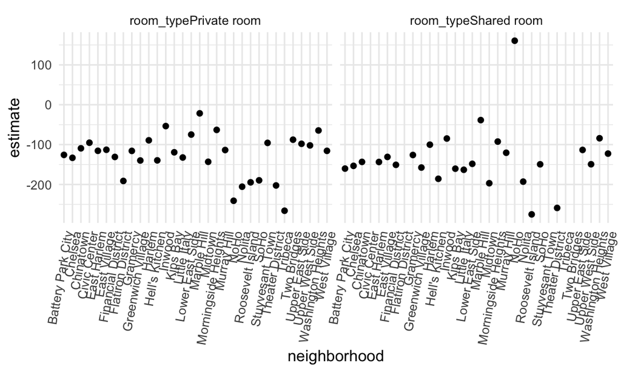

```r
manhattan_nest_lm_res %>%
  filter(str_detect(term, "room_type")) %>%
  ggplot(aes(x = neighborhood, y = estimate)) +
  geom_point() +
  facet_wrap(~term) +
  theme(axis.text.x = element_text(angle = 80, hjust = 1))
```

There is, generally speaking, a reduction in room price for a private room or a shared room compared to an entire apartment, but this varies quite a bit across neighborhoods.

With this many factor levels, it really isn’t a good idea to fit models with main effects or interactions for each. Instead, you’d be best-off using a mixed model, with random intercepts and slopes for each neighborhood

```r
manhattan_airbnb %>%
  lme4::lmer(price ~ stars + room_type + (1 + room_type | neighborhood), data = .) %>%
  broom.mixed::tidy()
```

```
## boundary (singular) fit: see ?isSingular
```

```
## # A tibble: 11 x 6
##    effect   group     term                          estimate std.error statistic
##    <chr>    <chr>     <chr>                            <dbl>     <dbl>     <dbl>
##  1 fixed    <NA>      (Intercept)                    250.        26.6      9.41
##  2 fixed    <NA>      stars                           -3.16       5.00    -0.631
##  3 fixed    <NA>      room_typePrivate room         -124.         7.80   -15.9
##  4 fixed    <NA>      room_typeShared room          -157.        12.9    -12.2
##  5 ran_pars neighbor… sd__(Intercept)                 59.3       NA       NA
##  6 ran_pars neighbor… cor__(Intercept).room_typePr…   -0.987     NA       NA
##  7 ran_pars neighbor… cor__(Intercept).room_typeSh…   -1.00      NA       NA
##  8 ran_pars neighbor… sd__room_typePrivate room       36.7       NA       NA
##  9 ran_pars neighbor… cor__room_typePrivate room.r…    0.992     NA       NA
## 10 ran_pars neighbor… sd__room_typeShared room        43.6       NA       NA
## 11 ran_pars Residual  sd__Observation                198.        NA       NA
```

## Binary outcomes

Logistic regression is useful for binary outcomes

- `lm()` assumes the error terms are iid with mean 0 and constant variance
  - assume the RV is normal (family = Gaussian)
- `glm()` generalizes the linear model into what is known as the exponential family.
  - allows for the obs to take on different RV (e.g. binomial, Poisson, multinomial)
  - must specify the family that the observations fall under.

```r
baltimore_df =
  read_csv("data/homicide-data.csv") %>%
  filter(city == "Baltimore") %>%
  mutate(
    resolved = as.numeric(disposition == "Closed by arrest"),
    victim_age = as.numeric(victim_age),
    victim_race = fct_relevel(victim_race, "White")) %>%
  select(resolved, victim_age, victim_race, victim_sex)
```

Using these data, we can fit a logistic regression for the binary “resolved” outcome and victim demographics as predictors. This uses the `glm` function with the family specified to account for the non-Gaussian outcome distribution.

```r
fit_logistic =
  baltimore_df %>%
  glm(resolved ~ victim_age + victim_race + victim_sex, data = ., family = binomial())
```

```r
fit_logistic %>%
  broom::tidy() %>%
  mutate(OR = exp(estimate)) %>%
  select(term, log_OR = estimate, OR, p.value) %>%
  knitr::kable(digits = 3)
```

[output not shown]

We can also compute fitted values; similarly to the estimates in the model summary, these are expressed as log odds and can be transformed to produce probabilities for each subject.

```r
baltimore_df %>%
  modelr::add_predictions(fit_logistic) %>%
  mutate(fitted_prob = boot::inv.logit(pred))
```

[output not shown]

# Cross Validation

- Cross validation provides a way to compare the predictive performance of competing methods.

## Cross validation – “by hand”

Start with a simulated example. The code chunk below generates data under a non-linear model.

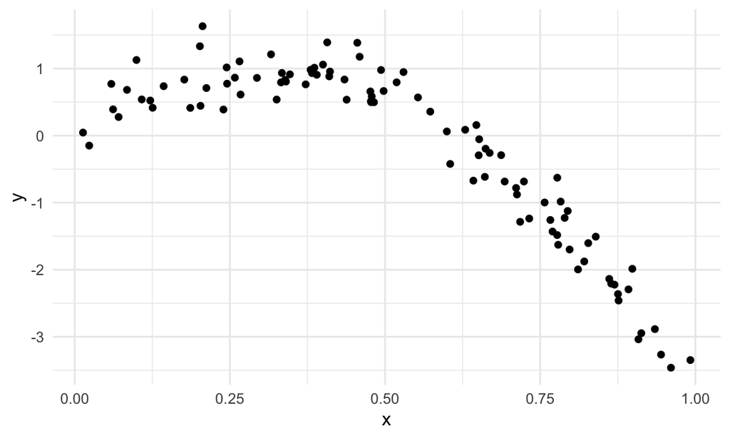

```r
nonlin_df =
  tibble(
    id = 1:100,
    x = runif(100, 0, 1),
    y = 1 - 10*(x - 0.3)^2 + rnorm(100, 0, 0.3)
  )

nonlin_df %>%
  ggplot(aes(x = x, y = y)) +
  geom_point()
```

Split this data into training and testing sets (using `anti_join`), and replot showing the split. Our goal will be to use the training data (in `black`) to build candidate models, and then see how these models predict in the testing data (in `red`).

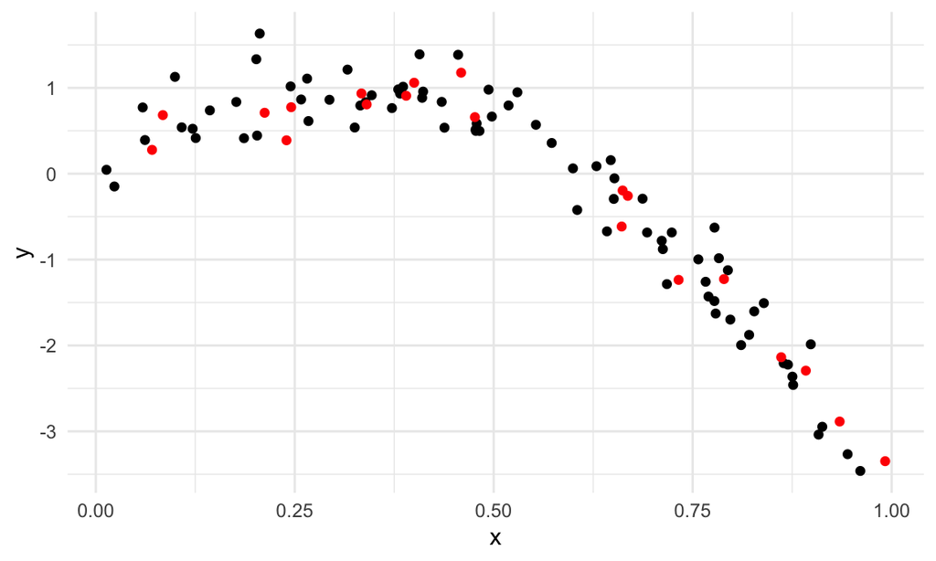

```r
train_df = sample_n(nonlin_df,size = 80)
test_df = anti_join(nonlin_df, train_df, by = "id")

ggplot(train_df, aes(x = x, y = y)) +
  geom_point() +
  geom_point(data = test_df, color = "red")
```

Fit three models to the training data.

- `mgcv::gam` package for non-linear models. The three models below have very different levels of complexity and arent’ nested, so testing approaches for nested model don’t apply.

```r
linear_mod = lm(y ~ x, data = train_df)
smooth_mod = mgcv::gam(y ~ s(x), data = train_df)
wiggly_mod = mgcv::gam(y ~ s(x, k = 30), sp = 10e-6, data = train_df)
```

To see what these models have done, plot the two `gam` fits

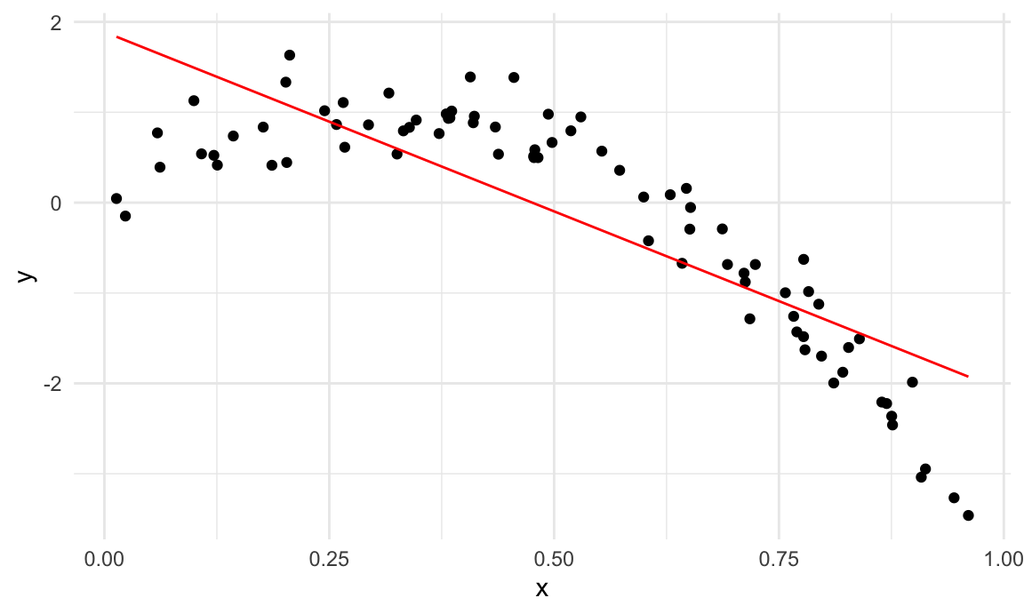

```r
train_df %>%
  add_predictions(linear_mod) %>%
  ggplot(aes(x = x, y = y)) +
  geom_point() +
  geom_line(aes(y = pred), color = "red")
```

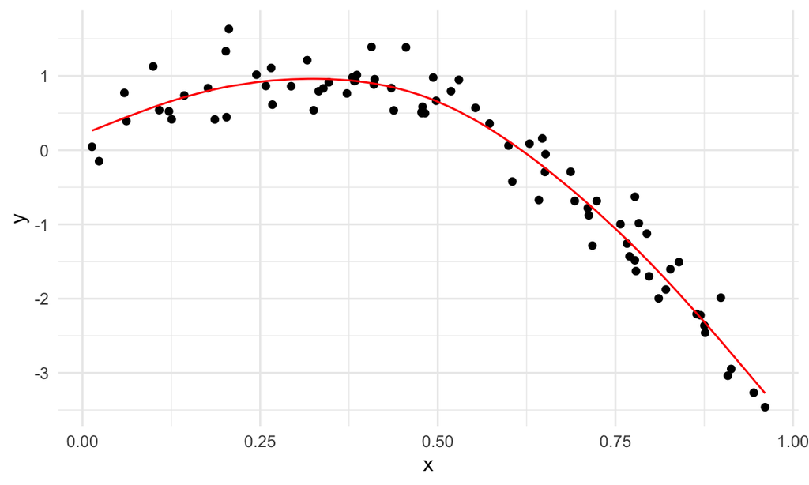

```r
train_df %>%
  add_predictions(smooth_mod) %>%
  ggplot(aes(x = x, y = y)) +
  geom_point() +
  geom_line(aes(y = pred), color = "red")   # this model works better
```

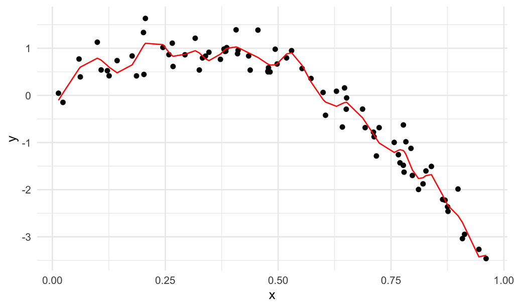

```r
train_df %>%
  add_predictions(wiggly_mod) %>%
  ggplot(aes(x = x, y = y)) +
  geom_point() +
  geom_line(aes(y = pred), color = "red")  # this makes bad prediction because it is chasing too much
```

Can use `modelr::gather_predictions` function to add predictions for several models to a data frame and then “pivoting”

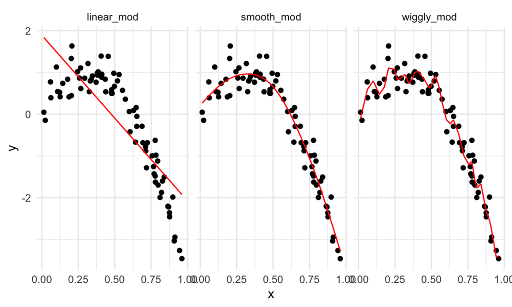

```r
train_df %>%
  gather_predictions(linear_mod, smooth_mod, wiggly_mod) %>%
  ggplot(aes(x = x, y = y)) +
  geom_point() +
  geom_line(aes(y = pred), color = "red") +
  facet_grid(. ~ model)
```

```r
# Linear model is too simple, never capture the true relationship between variables because of its simplicity. The standard `gam` fit is pretty good. The wiggly `gam` fit is too complex, chasing data points and will change a lot from one training dataset to the next. Smooth model should do best in term of accuracy.
```

Look at prediction accuracy: compute root mean squared errors (RMSEs) for each model

```r
rmse(linear_mod, test_df)
```

```
## [1] 0.7052956
```

```r
rmse(smooth_mod, test_df)
```

```
## [1] 0.2221774
```

```r
rmse(wiggly_mod, test_df)
```

```
## [1] 0.289051
```

*The `modelr` has other outcome measures - RMSE is the most common, but median absolute deviation is pretty common as well.* The RMSEs are suggestive that both nonlinear models work better than the linear model, and that the smooth fit is better than the wiggly fit. * To get a sense of model stability we need to iterate this whole process.

## CV using `modelr`

- `crossv_mc` performs the training/testing split multiple times and stores the datasets using list columns.

```r
cv_df =
  crossv_mc(nonlin_df, 100)
```

What is happening here…

```r
cv_df %>%  pull(train) %>% .[[1]] %>%  as_tibble()
```

```
## # A tibble: 79 x 3
##       id      x       y
##    <int>  <dbl>   <dbl>
##  1     1 0.266   1.11
##  2     2 0.372   0.764
##  3     3 0.573   0.358
##  4     4 0.908  -3.04
##  5     6 0.898  -1.99
##  6     7 0.945  -3.27
##  7     8 0.661  -0.615
##  8     9 0.629   0.0878
##  9    10 0.0618  0.392
## 10    11 0.206   1.63
## # … with 69 more rows
```

```r
cv_df %>%  pull(test) %>% .[[1]] %>%  as_tibble()
```

```
## # A tibble: 21 x 3
##       id      x      y
##    <int>  <dbl>  <dbl>
##  1     5 0.202   1.33
##  2    12 0.177   0.836
##  3    19 0.380   0.982
##  4    22 0.212   0.710
##  5    28 0.382   0.932
##  6    31 0.482   0.498
##  7    37 0.794  -1.12
##  8    42 0.647   0.158
##  9    47 0.0233 -0.148
## 10    56 0.0995  1.13
## # … with 11 more rows
```

`crossv_mc` tries to be smart about memory – rather than repeating the dataset a bunch of times, it saves the data once and stores the indexes for each training / testing split using a resample object. This can be coerced to a dataframe, and can often be treated exactly like a dataframe. However, it’s not compatible with gam, so we have to convert each training and testing dataset (and lose that nice memory-saving stuff in the process) using the code below. It’s worth noting, though, that if all the models you want to fit use lm, you can skip this.

```r
cv_df =
  cv_df %>%
  mutate(
    train = map(train, as_tibble),
    test = map(test, as_tibble)
  )
```

I now have many training and testing datasets, and I’d like to fit my candidate models above and assess prediction accuracy as I did for the single training / testing split. To do this, I’ll fit models and obtain RMSEs using **mutate** + **map** & **map2**.

```r
cv_df =
  cv_df %>%
  mutate(
    linear_mod  = map(train, ~lm(y ~ x, data = .x)),
    smooth_mod  = map(train, ~mgcv::gam(y ~ s(x), data = .x)),
    wiggly_mod  = map(train, ~gam(y ~ s(x, k = 30), sp = 10e-6, data = .x))
    ) %>%
  mutate(
    rmse_linear = map2_dbl(linear_mod, test, ~rmse(model = .x, data = .y)),
    rmse_smooth = map2_dbl(smooth_mod, test, ~rmse(model = .x, data = .y)),
    rmse_wiggly = map2_dbl(wiggly_mod, test, ~rmse(model = .x, data = .y))
    )
```

I’m mostly focused on RMSE as a way to compare these models, and the plot below shows the distribution of RMSE values for each candidate model.

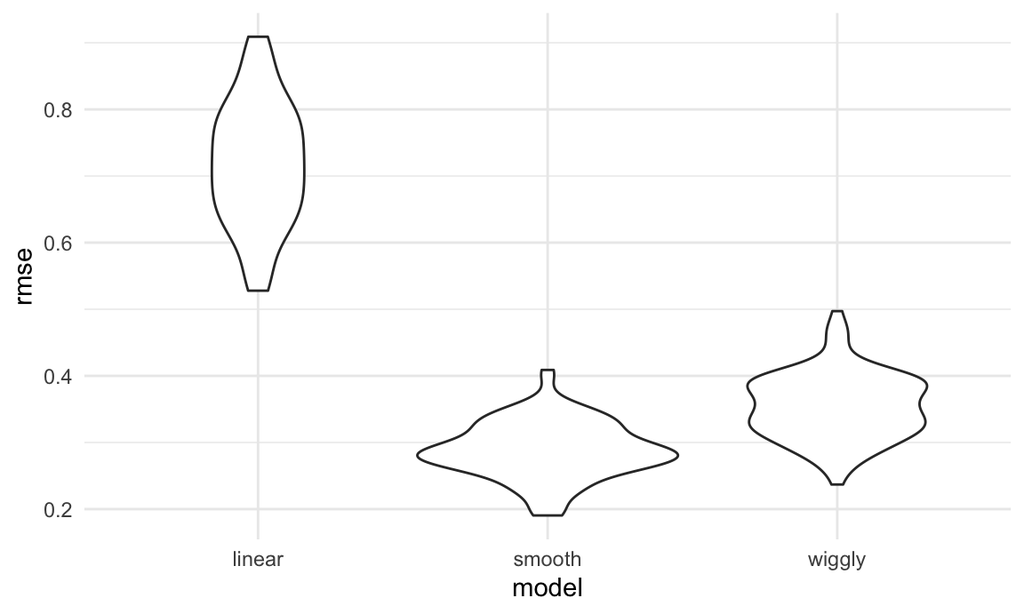

```r
cv_df %>%
  select(starts_with("rmse")) %>%
  pivot_longer(
    everything(),
    names_to = "model",
    values_to = "rmse",
    names_prefix = "rmse_"
  ) %>%
  ggplot(aes(x = model, y = rmse)) +
  geom_violin()
```

Compute averages…

```r
cv_df %>%
  select(starts_with("rmse")) %>%
  pivot_longer(
    everything(),
    names_to = "model",
    values_to = "rmse",
    names_prefix = "rmse_"
  ) %>%
  group_by(model) %>%
  summarize(avg_rmse = mean(rmse))
```

```
## # A tibble: 3 x 2
##   model  avg_rmse
##   <chr>     <dbl>
## 1 linear    0.718
## 2 smooth    0.289
## 3 wiggly    0.354
```

## Example: Child growth

- A cross-sectional study of Nepalese children was carried out to understand the relationships between various measures of growth, including weight and arm circumference.

#### import and look at the data

```r
child_growth =
  read_csv("data/nepalese_children.csv")
```

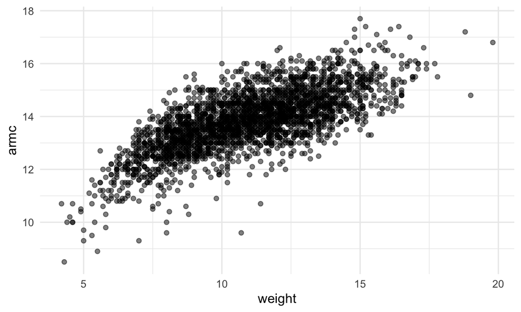

```r
child_growth %>%
  ggplot(aes(x = weight, y = armc)) +
  geom_point(alpha = .5)
```

```r
# The plots suggests some non-linearity, especially at the low end of the weight distribution. We’ll try three models: a linear fit; a piecewise linear fit; and a smooth fit using gam. For the piecewise linear fit, we need to add a “change point term” to our dataframe.
```

```r
child_growth =
  child_growth %>%
  mutate(weight_cp = (weight > 7) * (weight - 7))
```

```r
linear_mod = lm(armc ~ weight, data = child_growth)
pwlin_mod = lm(armc ~ weight + weight_cp, data = child_growth)  #piecewise linear model
smooth_mod = gam(armc ~ s(weight), data = child_growth)
```

Plot the three models to get intuition for goodness of fit

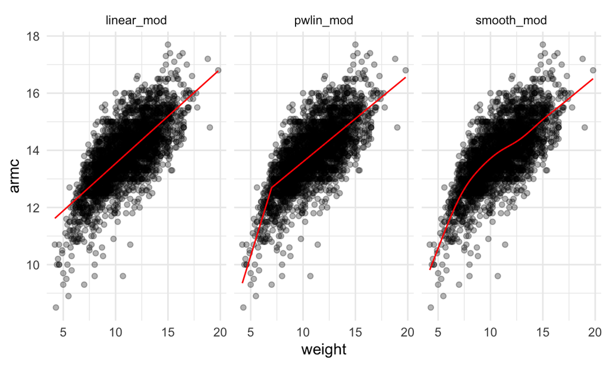

```r
child_growth %>%
  gather_predictions(linear_mod, pwlin_mod, smooth_mod) %>%
  ggplot(aes(x = weight, y = armc)) +
  geom_point(alpha = .3) +
  geom_line(aes(y = pred), color = "red") +
  facet_grid(. ~ model)
```

```r
#not clear which model is best => check prediction errors using the same process as before.
```

Try to understand model fit using CV.

```r
cv_df =
  crossv_mc(child_growth, 100) %>%
  mutate(
    train = map(train, as_tibble),
    test = map(test, as_tibble)
  )
```

Next I’ll use mutate + map & map2 to fit models to training data and obtain corresponding RMSEs for the testing data.

```r
cv_df =
  cv_df %>%
  mutate(
    linear_mod  = map(train, ~lm(armc ~ weight, data = .x)),
    pwl_mod     = map(train, ~lm(armc ~ weight + weight_cp, data = .x)),
    smooth_mod  = map(train, ~gam(armc ~ s(weight), data = as_tibble(.x)))
    ) %>%
  mutate(
    rmse_linear = map2_dbl(linear_mod, test, ~rmse(model = .x, data = .y)),
    rmse_pwl    = map2_dbl(pwl_mod, test, ~rmse(model = .x, data = .y)),
    rmse_smooth = map2_dbl(smooth_mod, test, ~rmse(model = .x, data = .y))
    )
```

Violin plots of RMSEs

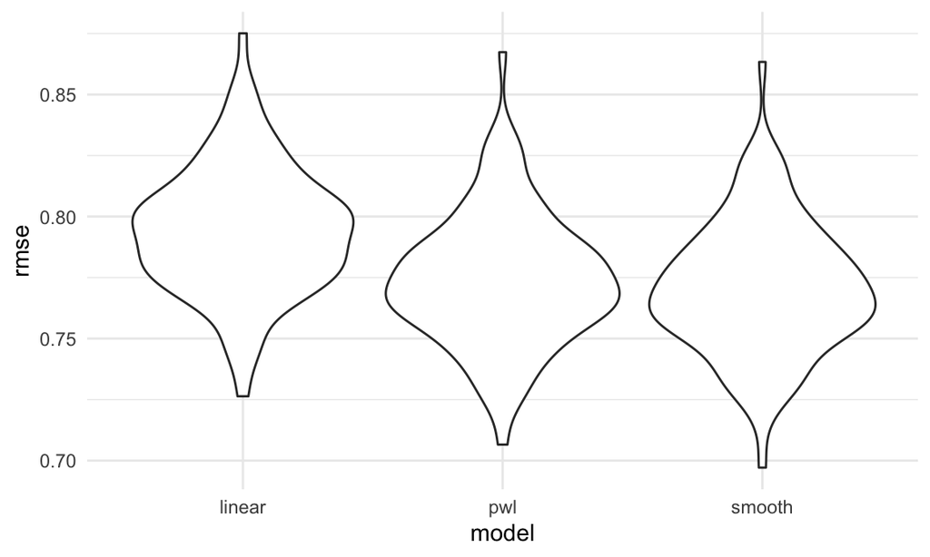

```r
cv_df %>%
  select(starts_with("rmse")) %>%
  pivot_longer(
    everything(),
    names_to = "model",
    values_to = "rmse",
    names_prefix = "rmse_"
  ) %>%
  ggplot(aes(x = model, y = rmse)) +
  geom_violin()
```

```r
# I’d probably go with the piecewise linear model – the non-linearity is clear enough that it should be accounted for, and the differences between the piecewise and gam fits are small enough that the easy interpretation of the piecewise model “wins”
```

# Bootstrapping

- Assumptions:
  - Sample means follow a known distribution
  - Regression coefficients follow a known distribution
  - Odds ratios follow a known distribution
- Process:
  - Write a function to: draw a sample with replacement, analyze the sample, return object of interest
  - Repeat this process many times

## Simulate data

```r
n_samp = 250

sim_df_const =
  tibble(
    x = rnorm(n_samp, 1, 1),
    error = rnorm(n_samp, 0, 1),
    y = 2 + 3 * x + error
  )

sim_df_nonconst =
  sim_df_const %>%
  mutate(
    error = error * 0.75 * x,
    y = 2 + 3 * x + error
  )
```

Plot the datasets

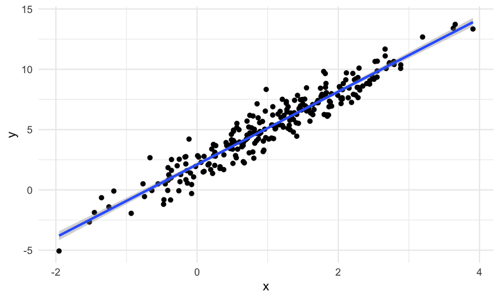

```r
sim_df_const %>%
  ggplot(aes(x = x, y = y)) +
  geom_point() +
  geom_smooth(method = "lm")
```

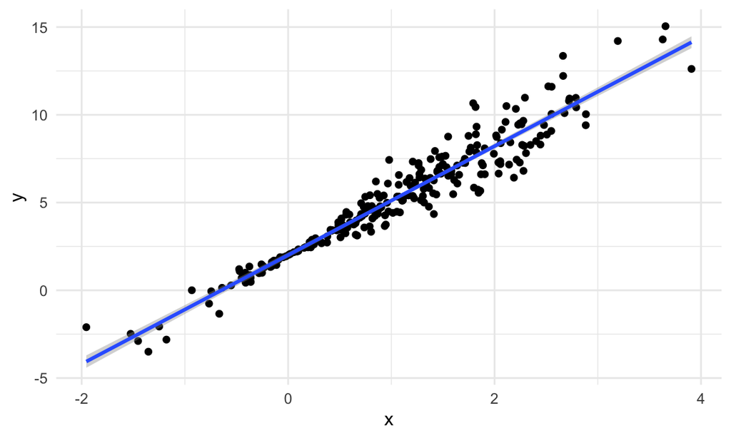

```r
sim_df_nonconst %>%
  ggplot(aes(x = x, y = y)) +
  geom_point() +
  geom_smooth(method = "lm")
```

fit a regression line

```r
lm( y ~ x, data = sim_df_const) %>% broom::tidy()
```

```
## # A tibble: 2 x 5
##   term        estimate std.error statistic   p.value
##   <chr>          <dbl>     <dbl>     <dbl>     <dbl>
## 1 (Intercept)     2.11    0.0860      24.5 3.76e- 68
## 2 x               3.02    0.0593      51.0 2.12e-133
```

```r
lm(y ~ x, data = sim_df_nonconst) %>% broom::tidy()
```

```
## # A tibble: 2 x 5
##   term        estimate std.error statistic   p.value
##   <chr>          <dbl>     <dbl>     <dbl>     <dbl>
## 1 (Intercept)     2.01    0.0818      24.5 2.58e- 68
## 2 x               3.10    0.0563      55.1 4.19e-141
```

## Draw one bootstrap sample

```r
boot_sample = function(df) {

  sample_frac(df, replace = TRUE) %>%
    arrange(x)

}
```

Check if this works…

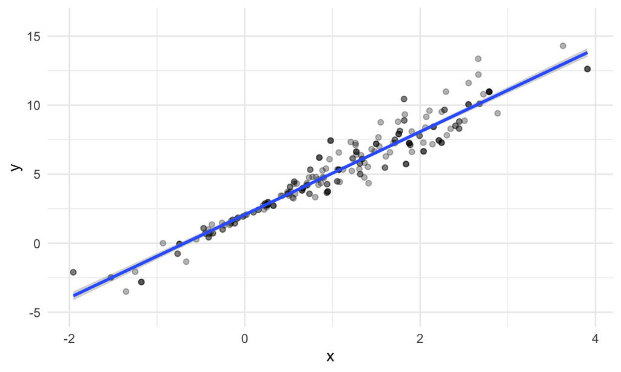

```r
boot_sample(sim_df_nonconst) %>%
  ggplot(aes(x = x, y = y)) +
  geom_point(alpha  = .3) +
  geom_smooth(method = "lm") +
  ylim(-5, 16)
```

```r
boot_sample(sim_df_nonconst) %>%
  lm(y ~ x, data = .) %>%
  broom::tidy()
```

```
## # A tibble: 2 x 5
##   term        estimate std.error statistic   p.value
##   <chr>          <dbl>     <dbl>     <dbl>     <dbl>
## 1 (Intercept)     1.93    0.0821      23.6 3.07e- 65
## 2 x               3.11    0.0527      59.0 6.11e-148
```

## Many samples and analysis

```r
boot_straps =
  tibble(
    strap_number = 1:1000,
    strap_sample = rerun(1000, boot_sample(sim_df_nonconst))
    )
```

Can I run my analysis on these…?

```r
boot_results =
  boot_straps %>%
  mutate(
    models = map(.x = strap_sample, ~lm (y ~ x, data = .x)),
    results = map(models, broom::tidy)
  ) %>%
  select(strap_number, results) %>%
  unnest(results)
```

What do I have now?

```r
boot_results %>%
  group_by(term) %>%
  summarize(
    mean_est = mean(estimate),
    sd_est = sd(estimate)
  )
```

```
## # A tibble: 2 x 3
##   term        mean_est sd_est
##   <chr>          <dbl>  <dbl>
## 1 (Intercept)     2.01 0.0583
## 2 x               3.10 0.0674
```

Look at the distributions

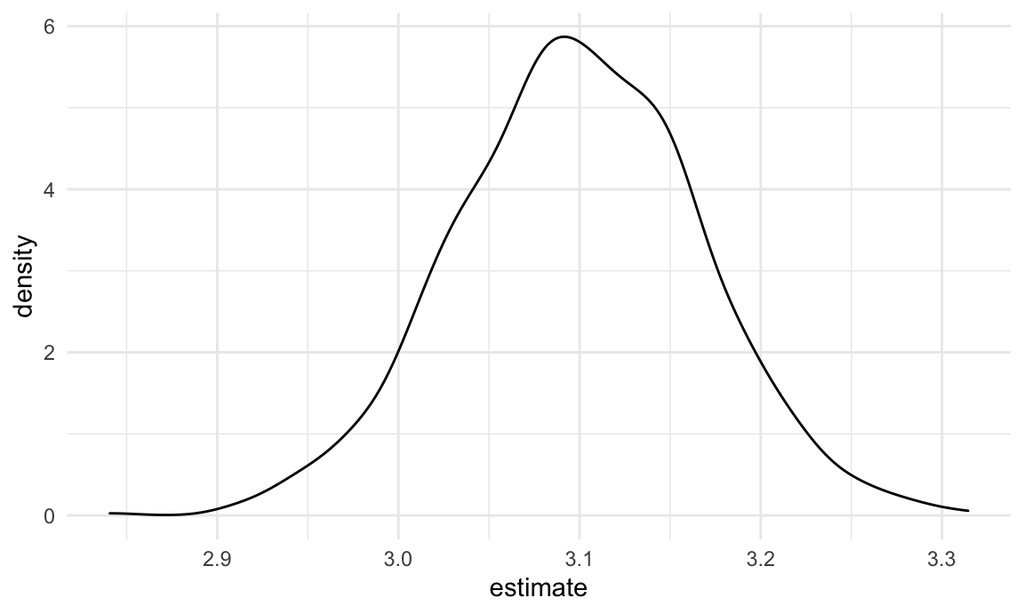

```r
boot_results %>%
  filter(term == "x") %>%
  ggplot(aes(x = estimate)) +
  geom_density()
```

Construct a bootstrap CI

```r
boot_results %>%
  group_by(term) %>%
  summarize(
    ci_lower = quantile(estimate, 0.025),
    ci_upper = quantile(estimate, 0.975)
  )
```

```
## # A tibble: 2 x 3
##   term        ci_lower ci_upper
##   <chr>          <dbl>    <dbl>
## 1 (Intercept)     1.90     2.13
## 2 x               2.97     3.23
```

## Boostrap using modelr

```r
sim_df_nonconst %>%
  bootstrap(1000, id = "strap_number") %>%
  mutate(
    models = map(.x = strap, ~lm (y ~ x, data = .x)),
    results = map(models, broom::tidy)
  ) %>%
  select(strap_number, results) %>%
  unnest(results) %>%
  group_by(term) %>%
  summarize(
    mean_est = mean(estimate),
    sd_est = sd(estimate)
  )
```

```
## # A tibble: 2 x 3
##   term        mean_est sd_est
##   <chr>          <dbl>  <dbl>
## 1 (Intercept)     2.01 0.0607
## 2 x               3.10 0.0659
```

## Revisit nyc airbnb

Reload the nyc airbnb dataset

```r
data("nyc_airbnb")

nyc_airbnb =
  nyc_airbnb %>%
  mutate(stars = review_scores_location / 2) %>%
  rename(
    borough = neighbourhood_group,
    neighborhood = neighbourhood) %>%
  filter(borough != "Staten Island") %>%
  select(price, stars, borough, neighborhood, room_type)
```

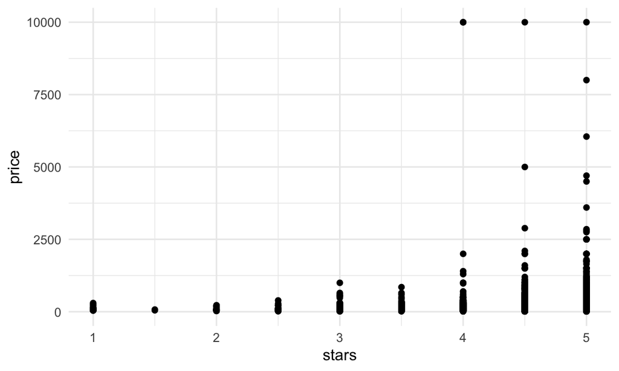

```r
nyc_airbnb %>%
  ggplot(aes(x = stars, y = price)) +
  geom_point()
```

```r
airbnb_boot_results =
  nyc_airbnb %>%
  filter(borough == "Manhattan") %>%
  drop_na(stars) %>%
  bootstrap(100, id = "strap_number") %>%
  mutate(
    models = map(.x = strap, ~lm (price ~ stars, data = .x)),
    results = map(models, broom::tidy)
  ) %>%
  select(strap_number, results) %>%
  unnest(results)

airbnb_boot_results %>%
  group_by(term) %>%
  summarize(
    mean_est = mean(estimate),
    sd_est = sd(estimate)
  )
```

```
## # A tibble: 2 x 3
##   term        mean_est sd_est
##   <chr>          <dbl>  <dbl>
## 1 (Intercept)    -35.6  30.0
## 2 stars           43.6   6.03
```

Compare this to `lm`

```r
nyc_airbnb %>%
  filter(borough == "Manhattan") %>%
  drop_na(stars) %>%
  lm(price ~ stars, data = .) %>%
  broom::tidy()
```

```
## # A tibble: 2 x 5
##   term        estimate std.error statistic  p.value
##   <chr>          <dbl>     <dbl>     <dbl>    <dbl>
## 1 (Intercept)    -34.3     22.9      -1.50 1.35e- 1
## 2 stars           43.3      4.78      9.07 1.39e-19
```

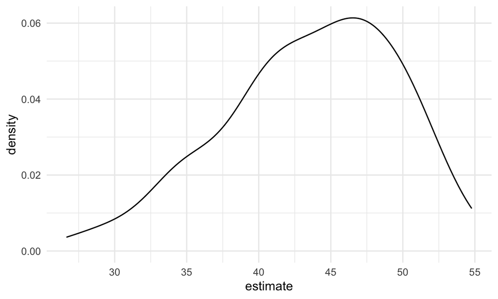

```r
airbnb_boot_results %>%
  filter(term == "stars") %>%
  ggplot(aes(x = estimate)) +
  geom_density()
```

# Live session - HW6

## Problem 1

Look at some variables: age, race and sex

```r
homicide_df =
  read_csv("data/homicide-data.csv", na = c("", "NA", "Unknown")) %>%
  mutate(
    city_state = str_c(city, state, sep = ", "),
    victim_age = as.numeric(victim_age),
    resolution = case_when(
      disposition == "Closed without arrest" ~ 0,
      disposition == "Open/No arrest"        ~ 0,
      disposition == "Closed by arrest"      ~ 1)
  ) %>%
  filter(
    victim_race %in% c("White", "Black"),
    city_state != "Tulsa, AL") %>%
  select(city_state, resolution, victim_age, victim_race, victim_sex)
```

[output not shown]

Start with one city

```r
baltimore_df =
  homicide_df %>%
  filter(city_state == "Baltimore, MD")
```

[output not shown]

```r
glm(resolution ~ victim_age + victim_race + victim_sex,
    data = baltimore_df,
    family = binomial()) %>%
  broom::tidy() %>%
  mutate(
    OR = exp(estimate),
    CI_lower = exp(estimate - 1.96 * std.error),
    CI_upper = exp(estimate + 1.96 * std.error)
  ) %>%
  select(term, OR, starts_with("CI")) %>%
  knitr::kable(digits = 3)
```

[output not shown]

Try this across cities

```r
models_results_df =
  homicide_df %>%
  nest(data = -city_state) %>%
  mutate(
    models = map(.x = data, ~glm(resolution ~ victim_age + victim_race + victim_sex, data = .x, family = binomial)),
    results = map(models, broom::tidy)
  ) %>%
  select(city_state, results) %>%
  unnest(results) %>%
  mutate(
    OR = exp(estimate),
    CI_lower = exp(estimate - 1.96 * std.error),
    CI_upper = exp(estimate + 1.96 * std.error)
  ) %>%
  select(city_state, term, OR, starts_with("CI"))
```

[output not shown]

```r
models_results_df %>%
  filter(term == "victim_sexMale") %>%
  mutate(city_state = fct_reorder(city_state, OR)) %>%
  ggplot(aes(x = city_state, y = OR)) +
  geom_point() +
  geom_errorbar(aes(ymin = CI_lower, ymax = CI_upper)) +
  theme(axis.text.x = element_text(angle = 90, hjust = 1))
```

[output not shown]

## Problem 2

some variables: birthweight, sex, bwt, gaweeks, momage, parity, smoken

build the model: by looking thru these variables and come up with reasons why you put them in. or go all out and variable selection?

Compare in term of prediction accuracy and prediction errors.

```r
# Find some residuals

baby_df =
  read_csv("data/birthweight.csv")
```

[output not shown]

```r
# Fit a model

model_fit = lm(bwt ~ gaweeks, data = baby_df) #can make a scatterplot with y = bwt,x = gastational weeks
```

[output not shown]

```r
# add residuals
baby_df %>%
  modelr::add_residuals(model_fit) %>%
  ggplot(aes(x = resid)) +
  geom_density() #residuals are not heavily skewed.
```

[output not shown]

```r
baby_df %>%
  modelr::add_residuals(model_fit) %>%
  ggplot(aes(x = gaweeks, y = resid)) +
  geom_point() #everything centered around 0.
```

[output not shown]

## Problem 3

use bootstraps to obtain distribution for parameters interested in. Fit a linear model of tmax and tmin. Proporiton of r squared value (broom::glance) and log of (bo + b1) (broom::tidy)